# COVID death lag discussion

```r
library(tidyverse)
library(sn)
library(gridExtra)

# Set basic theme for plots
theme_hcb <- theme_classic() +
             theme(panel.grid.major.y=element_line(colour = 'lightgrey')
              )
theme_set(theme_hcb)

set.seed(55555)
```

Government agencies don’t always post the data that would be the best to use. NSW Health publishes daily cases and daily deaths for covid, as well as some summary statistics in the Weekly Surveillance Reports. To calculate the death rate for COVID using the daily figures it is necessary to account for the lag between testing positive and passing away. This is pretty straightforward, but what should the lag be?

The weekly surveillance reports published by NSW Health<sup>4</sup> state a median lag of 11 days from symptom onset to death. This has been consistent throughout the second half of 2021 where Delta was the dominant variant in NSW. It is also possible to calculate the observed lag by comparing case numbers and death numbers which shows a lag of 20 days<sup>2</sup>. This is a big difference! The observed lag is almost double the median.

These numbers point to a flat, heavily skewed distribution<sup>1</sup>. It should be possible to approximate it with a series of Poisson distributions, but without more information it’s just guessing. What is possible is to define a distribution that has some of the observed properties and see what happens when it is applied to real world data. This should help explain the difference in the median lag and the observed lag and inform the choice of lag time.

```r
# Skewed distribution to approximate observed data
om=15
al=6
del=1
sn = rsn(n=10000, xi=del, omega=om, alpha=al)
sn = sn[sn>=0]
```

A skewed normal distribution was used to approximate the data. The median was set to match the NSW Health figure of 11 days, with a shape resembling those published by UK Health<sup>1</sup>. The UK Health data corresponds to the original strain, but it works to demonstrate the effect shown here.

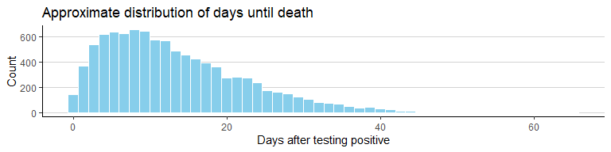

```r
SN=data.frame(sn)

# Plot approximation
ggplot(data = SN, mapping = aes(x=sn)) +
  geom_histogram(
    color='white',
    fill='skyblue',
    bins=50
  ) +
  labs(
    x='Days after testing positive',
    y='Count',
    title='Approximate distribution of days until death'
  )
```

Summary statistics for the model distribution:

```r
# Summary stats for generated data
summary(sn)
```

```
   Min. 1st Qu.  Median    Mean 3rd Qu.    Max.
  0.006   6.237  11.480  13.288  18.571  65.277
```

This corresponds to the distribution of deaths from one day of infections. Using the case number data from NSW Health, it should be possible to re-create the general shape of the death data. To do this a random sample is taken from our model distribution for each day, with the sample size being the case number for that day.

Not that due to the relatively small number of cases each day, rather than take a percentage of cases to reflect the death rate no scaling has been done. The purpose here is to show how the difference in lag occurs, so the overall shapes are more important than the number totals.

For reference, below are the daily cases and daily deaths as reported.

```r
# Read in case data and select NSW
cases = read.csv('cases_daily_state_NET.csv')
cases <- rename(cases, Date=ï..Date)
cases <- subset(cases, select=c(Date,NSW))
# Convert date format and select time period of interest
cases$Date <- as.Date(cases$Date, '%d/%m/%y')
cases <- cases %>% filter(Date>'2021-06-15' & Date<'2021-10-31')
# Convert count format
cases$NSW <- as.numeric(gsub(",", "", cases$NSW))

# Read in deaths data and select NSW
deaths <- read.csv('deaths_daily_state.csv')
deaths <- rename(deaths, Date=ï..Date)
deaths <- subset(deaths, select = c(Date, NSW))
# Convert date format and select time period of interest
deaths$Date <- as.Date(deaths$Date, '%d/%m/%y')
deaths <- deaths %>% filter(Date>'2021-06-15' & Date<'2021-10-31')
# Convert count format
deaths$NSW <- as.numeric(gsub(",", "", deaths$NSW))
```

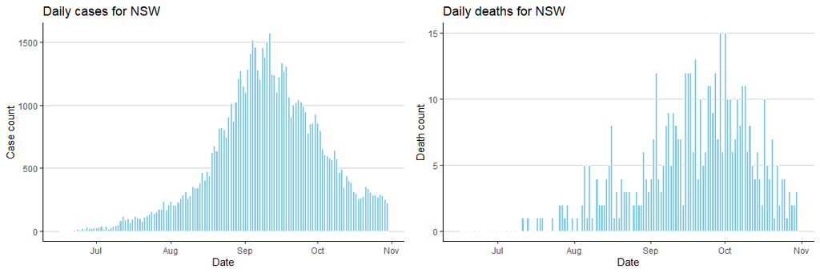

```r
# Plot daily cases
c_plot <- ggplot(cases, mapping=aes(Date, NSW))+
  geom_col(
    color='white',
    fill='skyblue'
  )+
  labs(
    x='Date',
    y='Case count',
    title='Daily cases for NSW'
  )

# Plot daily deaths
d_plot <- ggplot(deaths, mapping=aes(Date, NSW))+
  geom_col(
    color='white',
    fill='skyblue'
  )+
  labs(
    x='Date',
    y='Death count',
    title='Daily deaths for NSW'
  )

grid.arrange(c_plot, d_plot, ncol=2)
```

```r
# Create distributions for each days cases
# Make data frame with distributions
DS = data.frame(pos=integer(),day=character())
for(i in 1:length(cases$NSW))
{
  # generate distribution for that days positive tests + num days since start
  pos_tests = cases$NSW[i]
  if (pos_tests > 0) {
    d_dist <- rsn(n=pos_tests, xi=del, omega=om, alpha=al)
    d_dist <- d_dist[d_dist>=0]+i
    cat = as.character(i)
    d_dist <- data.frame(d_dist, cat) %>% rename(deaths=d_dist,day=cat)
    DS <- rbind(DS, d_dist)
  }
}
```

First, the distributions from each days data are laid over each other.

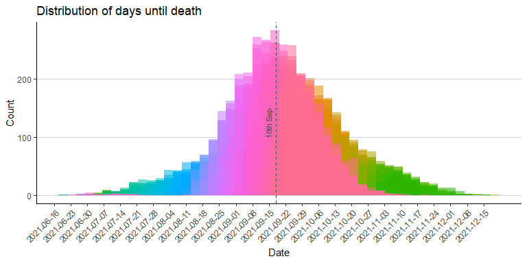

```r
# Set up date labels for x axis
start <- as.Date('2021-06-16')
x_ax <- seq(0, max(as.numeric(DS$day))+49, 7)

# Plot histograms overlaid on each other
ggplot(DS, aes(x=deaths, alpha=0.3, fill=day)) +
  geom_histogram(
    position = 'identity',
    bins=50
  ) +
  labs(
    x='Date',
    y='Count',
    title='Distribution of days until death'
  ) +
  geom_vline(
    xintercept=94,
    colour='darkslategrey',
    linetype='dashed'
  ) +
  annotate(
    geom='text',
    x=94,
    y=125,
    vjust=-.8,
    angle=90,
    size=3,
    label="18th Sep",
    colour='darkslategrey'
  ) +
  theme(legend.position = "none",
        axis.text.x = element_text(angle=45, vjust=1, hjust=1)
  ) +
  scale_x_continuous(
    breaks=x_ax,
    labels=start + x_ax
  )
```

Next the distributions are stacked, note the change in the y-axis.

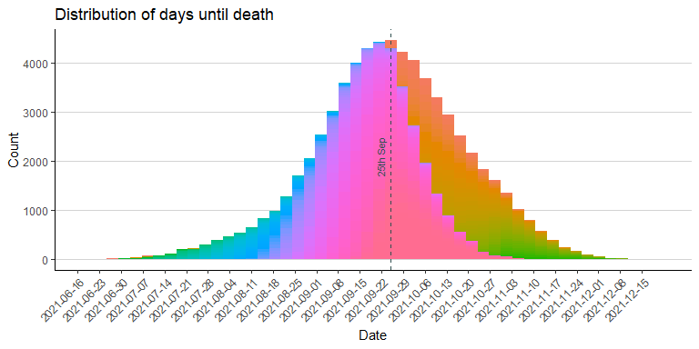

```r
# Stack histograms to get cumulative shape
ggplot(DS, aes(x=deaths, fill=day)) +
  geom_histogram(
    bins=50
  ) +labs(
    x='Date',
    y='Count',
    title='Distribution of days until death'
  ) +
  geom_vline(
    xintercept=101,
    colour='darkslategrey',
    linetype='dashed'
  ) +
  annotate(
    geom='text',
    x=101,
    y=2100,
    vjust=-.8,
    angle=90,
    size=3,
    label="25th Sep",
    colour='darkslategrey'
  ) +
  theme(legend.position = "none",
        axis.text.x = element_text(angle=45, vjust=1, hjust=1)
  ) +
  scale_x_continuous(
    breaks=x_ax,
    labels=start+x_ax
  )
```

Now the highest point has shifted to the 25th September, a 15 day lag. So we can see how a skewed distribution can affect the observed peak when deaths from cases on different days are all added together, as we get in the reported numbers.

It is also clearer now that using the median as the lag will produce a less accurate estimation of the death rate when looking at the deaths reported each day - it will under-estimate as cases increase and over-estimate as cases decrease. Aligning the peaks of the case numbers and the daily deaths will give the best approximation.

#### References

1. COVID-19 Clinical Information Network (CO-CIN), *Time from symptom onset until death in UK hospitalised patients*, 7 October 2020, https://www.gov.uk/government/publications/co-cin-covid-19-time-from-symptom-onset-until-death-in-uk-hospitalised-patients-7-october-2020
2. Mike Honey 2021, accessed 23 December 2021, https://github.com/Mike-Honey/covid-19-hospitalisations
3. NSW Ministry of Health 2021, accessed 23 December 2021, https://www.nsw.gov.au/covid-19/stay-safe/data-and-statistics#map-of-nsw-covid-19-positive-cases-and-testing-by-postcode
4. NSW Ministry of Health 2021, accessed 23 December 2021, https://www.health.nsw.gov.au/Infectious/covid-19/Pages/weekly-reports.aspx